# Reproducible Research: Peer Assessment 1

### Problem background (from assignment):

[output not shown]

## Part1: Loading and preprocessing the data

Show any code that is needed to

- Load the data (i.e. read.csv())
- Process/transform the data (if necessary) into a format suitable for your analysis

```r
# Part 1: solution
activity <- read.csv("activity.csv")
activity$date2 <- as.Date(activity$date, format = "%Y-%m-%d")  #formatted date
```

## Part2: What is mean total number of steps taken per day?

- For this part of the assignment, you can ignore the missing values in the dataset.
- Make a histogram of the total number of steps taken each day
- Calculate and report the mean and median total number of steps taken per day

```r
#part2: Solution
#daily summary: Do calculations first, then plot and report answers in end

d<- data.frame(unique(activity$date2)) #just the dates for aggregation
names(d)<- "date2"

for (i in 1:nrow(d)) #loop through each date
{
  t<- activity[activity$date2==d[i,1],1] #store current date in t
  d[i,2]<- sum(t, na.rm = TRUE)   #aggregate and keep adding to data frame d (one value for each date)
  d[i,3]<- mean(t, na.rm = TRUE)
  d[i,4]<- median(t, na.rm = TRUE)
}
names(d)<- c("Date", "Total Steps", "Mean Steps", "Median Steps")

# library(graphics) #load library to plot
```

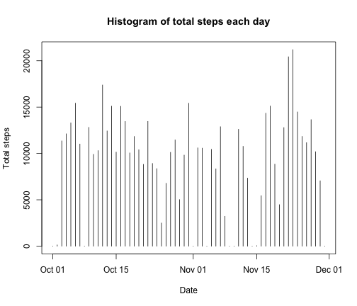

```r
plot(d[, 1], d[, 2], type = "h", xlab = "Date", ylab = "Total steps", main = "Histogram of total steps each day")
```

Mean and Median of total steps taken per day

```r
print(c("Mean = ", mean(d[, 2])))
```

```
## [1] "Mean = "          "9354.22950819672"
```

```r
print(c("Median =", median(d[, 2])))
```

```
## [1] "Median =" "10395"
```

Data table of mean and median steps each day

```r
print(d[, c(1, 3, 4)])
```

```
##          Date Mean Steps Median Steps
## 1  2012-10-01        NaN           NA
## 2  2012-10-02     0.4375            0
## 3  2012-10-03    39.4167            0
## 4  2012-10-04    42.0694            0
## 5  2012-10-05    46.1597            0
## 6  2012-10-06    53.5417            0
## 7  2012-10-07    38.2465            0
## 8  2012-10-08        NaN           NA
## 9  2012-10-09    44.4826            0
## 10 2012-10-10    34.3750            0
## 11 2012-10-11    35.7778            0
## 12 2012-10-12    60.3542            0
## 13 2012-10-13    43.1458            0
## 14 2012-10-14    52.4236            0
```

[output cut: 47 more lines]

Median is all 0 because more than 50% users took 0 steps on all days, which pushed median to 0

## Part3: What is the average daily activity pattern?

- Make a time series plot (i.e. type = “l”) of the 5-minute interval (x-axis) and the average number of steps taken, averaged across all days (y-axis)
- Which 5-minute interval, on average across all the days in the dataset, contains the maximum number of steps?

```r
#part3: interval summary
d<- data.frame(unique(activity$interval)) #just the intervals for aggregation
names(d)<- "interval"

for (i in 1:nrow(d)) #loop through each interval
{
  t<- activity[activity$interval==d[i,1],1] #store current number of steps in t, for current interval
  d[i,2]<- mean(t, na.rm = TRUE) #average steps for line plot
  d[i,3]<- sum(t, na.rm=TRUE) #total steps to calculate max later
}

names(d)<- c("interval", "average_steps", "total_steps")
```

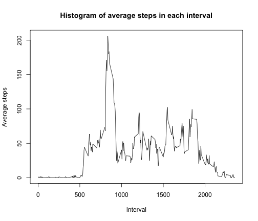

```r
plot(d[, 1], d[, 2], type = "l", xlab = "Interval", ylab = "Average steps",
    main = "Histogram of average steps in each interval")
```

```r
# interval with maximum number of total steps
print(d[d$total_steps == max(d$total_steps), 1])
```

```
## [1] 835
```

## Part4: Imputing missing values

Note that there are a number of days/intervals where there are missing values (coded as NA). The presence of missing days may introduce bias into some calculations or summaries of the data.

```r
# Code for part 4
print(c("Number of missing values - ", sum(!complete.cases(activity))))
```

```
## [1] "Number of missing values - " "2304"
```

Strategy for imputation: Use recently calculated mean from each interval, and plug it in where NA. Another dataset 'a' is created for storing revised data with imputed values

```r
a<- activity
for (i in 1:nrow(a)) #For each row in data frame a
{
  if(is.na(a[i,1])) #if value is null, then
    {
    t<- a[i,3]
    a[i,1]<- d[d[,1]==t,2] #replace with value for time interval, when interval matches with aggregated dataset recently computed
    }
}


#Original data frame 'd' not needed anymore. Reusing below for date level aggregation for creating plots on new data.

d<- data.frame(unique(a$date2)) #just the dates for aggregation
names(d)<- "date2"

for (i in 1:nrow(d)) #loop through each date
{
  t<- a[a$date2==d[i,1],1] #store current date in t
  d[i,2]<- sum(t, na.rm = TRUE)   #aggregate and keep adding to data frame d (one value for each date)
  d[i,3]<- mean(t, na.rm = TRUE)
  d[i,4]<- median(t, na.rm = TRUE)
}
names(d)<- c("Date", "Total Steps", "Mean Steps", "Median Steps")
```

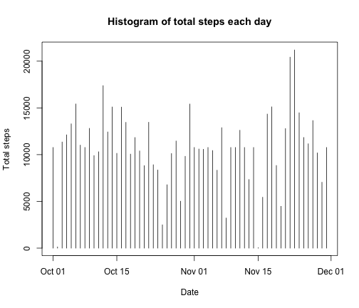

```r
plot(d[, 1], d[, 2], type = "h", xlab = "Date", ylab = "Total steps", main = "Histogram of total steps each day")
```

```r
print(d[, c(1, 3, 4)])
```

```
##          Date Mean Steps Median Steps
## 1  2012-10-01    37.3826        34.11
## 2  2012-10-02     0.4375         0.00
## 3  2012-10-03    39.4167         0.00
## 4  2012-10-04    42.0694         0.00
## 5  2012-10-05    46.1597         0.00
## 6  2012-10-06    53.5417         0.00
## 7  2012-10-07    38.2465         0.00
## 8  2012-10-08    37.3826        34.11
## 9  2012-10-09    44.4826         0.00
## 10 2012-10-10    34.3750         0.00
## 11 2012-10-11    35.7778         0.00
## 12 2012-10-12    60.3542         0.00
## 13 2012-10-13    43.1458         0.00
## 14 2012-10-14    52.4236         0.00
```

[output cut: 47 more lines]

Please note that some of the medians are non zero now, because of adjustment for missing values. Since the imputation was done by interval, the aggregation shows comparable values when aggregated by date.

## Part5: Are there differences in activity patterns between weekdays and weekends?

For this part the weekdays() function may be of some help here. Use the dataset with the filled-in missing values for this part.

- Create a new factor variable in the dataset with two levels – “weekday” and “weekend” indicating whether a given date is a weekday or weekend day.
- Make a panel plot containing a time series plot (i.e. type = “l”) of the 5-minute interval (x-axis) and the average number of steps taken, averaged across all weekday days or weekend days (y-axis).

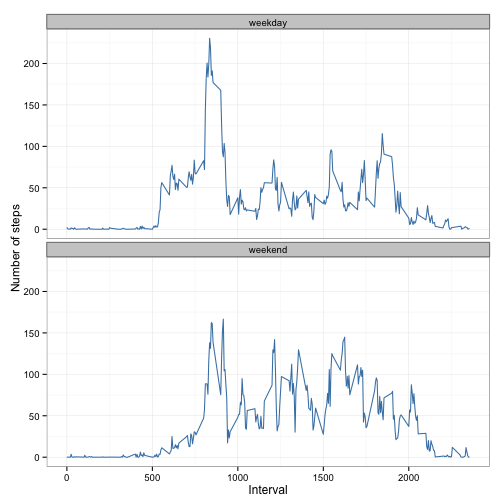

```r
# code for part 5 Define columns in new imputed dataset 'a' for weekday and
# weekend
a$weekday <- weekdays(a$date2)  #Gives which day it is (7 values)
a$w_tf <- a$weekday == "Saturday" | a$weekday == "Sunday"  # Boolean for wekend or weekday
a$wday_flag <- factor(a$w_tf, labels = c("weekday", "weekend"))  #Final column with right formatting

# Create aggregated dataset for weekend vs weekday average steps plot
library(sqldf)
a_part5 <- sqldf("select wday_flag, interval, avg(steps) as avg_steps\n                from a\n                group by wday_flag, interval")
# Actual plot code
library(ggplot2)
plot_part5 <- function() {
    ggplot(data = a_part5, aes(x = interval, y = avg_steps)) + geom_line(color = "steelblue",
        size = 0.5) + facet_wrap(~wday_flag, nrow = 2, ncol = 1) + theme_bw() +
        xlab("Interval") + ylab("Number of steps")
}
plot_part5()
```